# Adamic BIOL 7263 Home Webpage

Emily Adamic

9/1/2022

# Introduction

### Educational Experience

Degree

Major

Year

School

Location

B.S.Ed

Exercise Science

2016

[figure not shown]

*University of Memphis*

Memphis, TN

M.S.

Exercise Physiology

2020

[figure not shown]

*Indiana University*

Bloomington, IN

Ph.D.

Biological Sciences

TBD

[figure not shown]

*University of Tulsa*

Tulsa, OK

### Research Interests

> How does the brain use internal signals to regulate the body?

> How do these signals interact with intrinsic brain activity for conscious feelings?

I address these questions in my PhD research, working under Dr. Sahib Khalsa at the Laureate Institute for Brain Research. For a broader view of our lab, see Dr. Khalsa’s lab website found [here](https://www.laureateinstitute.org/sahib-khalsa.html).

Internal signals regarding the state of the body constantly emanate to the central nervous system (CNS). The CNS must then integrate these signals across disparate receptors and body systems, and issue the proper motor commands to help these signals stay within homeostatic ranges. This regulation can also occur prospectively as the brain learns new contexts, predicts future needs, and regulates the body preemptively. While these internal body signals are to inform this regulation, these signals also contribute to subjective feeling states and the constant stream of consciousness which are cores of the human experience. These conscious sensations of the body, if maladaptive, play an important role in many symptoms of psychiatric disorders such as anxiety and depression. Understanding how the body talks to the brain, and how the brain regulates the body, is thus important for physical and mental health and performance.

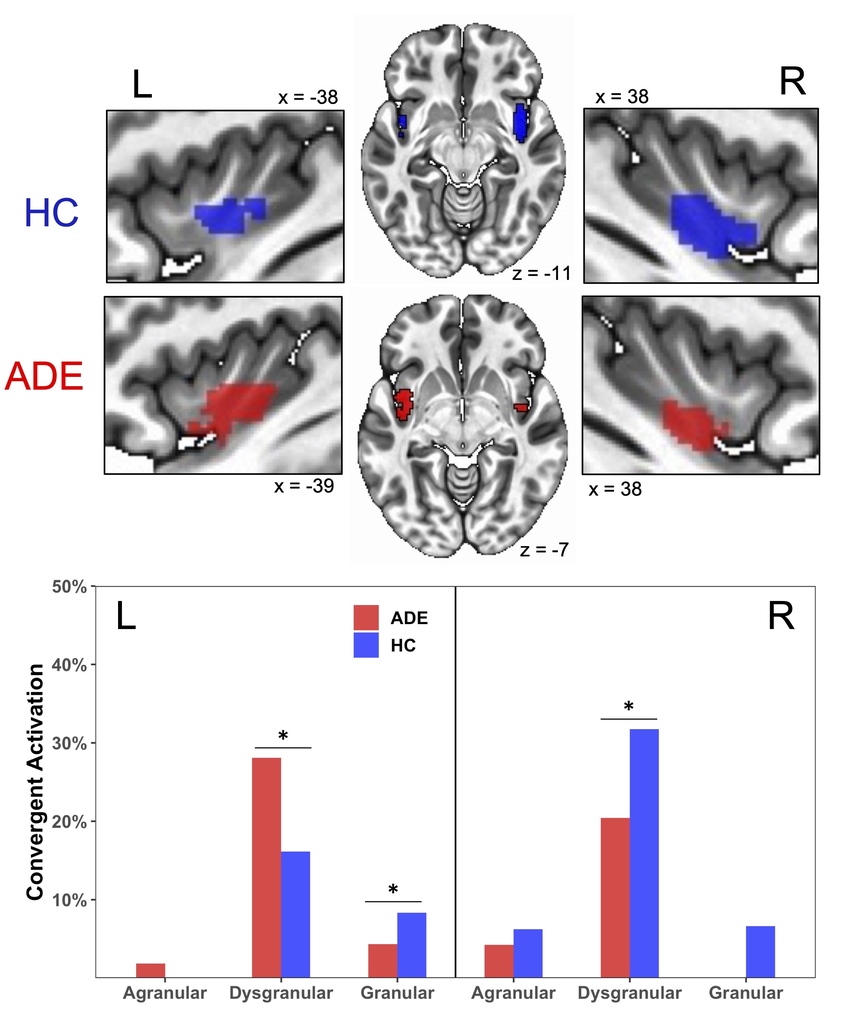

*Figure 1. Identifying what subregions of the insular cortex receive bottom-up signals that are then accessible to top-down attention towards and conscoius awareness of the body, in both healthy comparisons (HC) and a sample of anxieyt, depression, and eating disorder patients (ADE).*

# Assignments

| Date | Description | Link |
| --- | --- | --- |
| 09/01/22 | Hello world | Assignment 1 |
| TBD (Assn 3) | Text editing | TBD |
| 10-02-22 | Wrangling | Assignment 4 |
| 10-02-22 | Tidying | Assignment 5 |
| 10-13-22 | Ggplotting | Assignment 6 |